# Solving the Data Science Dilemma

From “R *or* Python” to “R *and* Python”

Ketchbrook Analytics

2/18/2020

```r
# Run once:
# install.packages(c("reticulate",
#                    "dplyr",
#                    "ggplot2",
#                    "RSocrata",
#                    "reshape2",
#                    "lubridate"))

library(dplyr)
library(ggplot2)
library(RSocrata)
library(reshape2)
library(lubridate)
library(xts)
library(here)

# Run once:
# reticulate::py_install("pandas")
# reticulate::py_install("statsmodels")

# Import custom functions from 'functions.R' file
source(
  here::here(
    "functions.R"
  )
)


library(reticulate)
reticulate::use_virtualenv(virtualenv = "r-reticulate")
reticulate::py_available(TRUE)
```

```
## [1] TRUE
```

```python
# Python

import pandas as pd
from statsmodels.tsa.vector_ar.var_model import VAR
```

## Project - Predicting the CT Prison Population

The prison population data can be found in the [CT Open Data Repository](https://data.ct.gov/Public-Safety/Correctional-Facility-Daily-Population-Count-By-Fa/n8x6-s299).

We’ll also use some data on monthly CT non-farm employment statistics to use as a regressor variable to hopefully help us predict the prison population. This data is also accessible via the [CT Open Data Repository](https://data.ct.gov/Government/Department-of-Labor-Office-of-Research-Current-Emp/8zbs-9atu)

### Import data using R

```r
my_data <- GetData()
```

Now we have an R dataframe named **my_data** in memory. Let’s take a look at the first few rows of data, some summary statistics, and the observations with the lowest total state prison population.

But… let’s use Python to do so:

### Profiling Data using Python and calling R dataframe with “r.”

```python
# Python

# We can execute Python against R dataframe objects by prepending the R dataframe name with 'r.'

r.my_data.head()
```

```
##          date  total.state.prison.pop  total.nonfarm.employed
## 0  2010-01-01                   18053                  1568.7
## 1  2010-02-01                   18383                  1576.8
## 2  2010-03-01                   18330                  1582.6
## 3  2010-04-01                   18331                  1607.8
## 4  2010-05-01                   18259                  1625.9
```

```python
# Python

# We can execute Python against R dataframe objects by prepending the R dataframe name with 'r.'

r.my_data.describe()
```

```
##        total.state.prison.pop  total.nonfarm.employed
## count              120.000000              120.000000
## mean             15867.900000             1663.920000
## std               1689.618526               33.632939
## min              12530.000000             1568.700000
## 25%              14405.000000             1639.725000
## 50%              16324.500000             1667.450000
## 75%              17032.750000             1692.775000
## max              18593.000000             1719.100000
```

```python
# Python

# We can execute Python against R dataframe objects by prepending the R dataframe name with 'r.'

r.my_data.sort_values(by = 'total.state.prison.pop').head()
```

```
##            date  total.state.prison.pop  total.nonfarm.employed
## 119  2019-12-01                   12530                  1717.5
## 118  2019-11-01                   12793                  1719.1
## 117  2019-10-01                   12935                  1709.8
## 116  2019-09-01                   12941                  1704.2
## 113  2019-06-01                   13001                  1712.9
```

## Preparing Data for Forecasting

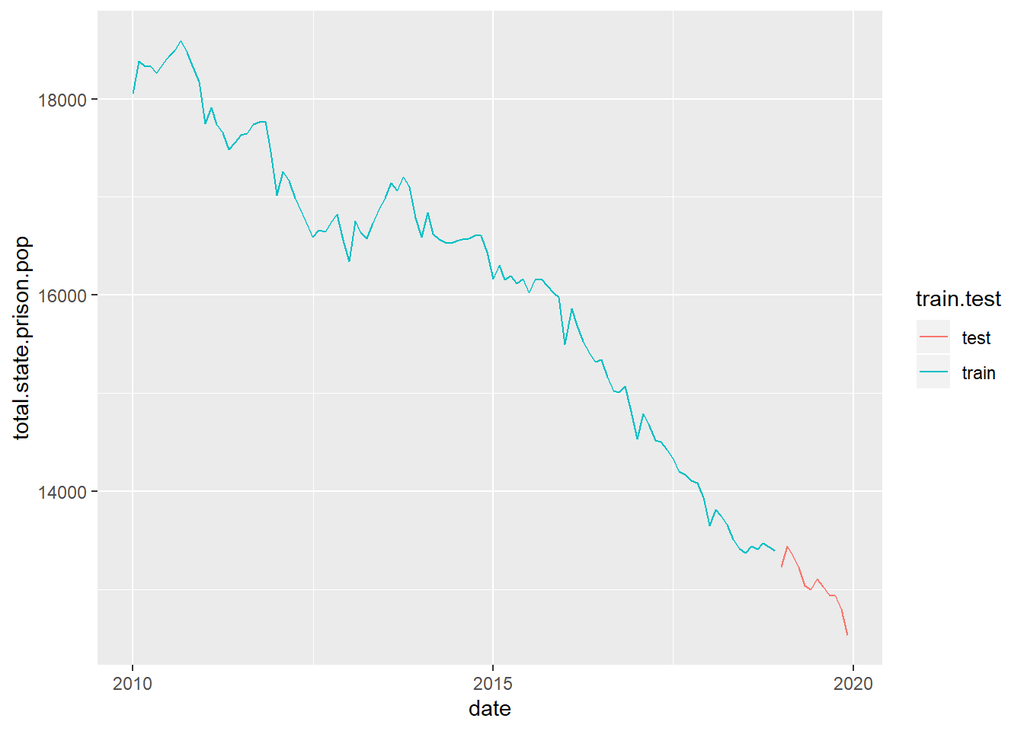

```r
# Split the data into "train" and "test" sets
# We'll train the model on the "train" data, and evaluate how accurate the model makes predictions using the "test data
train_df <- my_data %>%
  dplyr::filter(date < as.Date("2019-01-01"))

test_df <- my_data %>%
  dplyr::filter(date >= as.Date("2019-01-01"))

# Visualize the train/test data split
ggplot2::ggplot(
  my_data %>%
    dplyr::mutate(train.test = ifelse(date < as.Date("2019-01-01"),
                                      "train",
                                      "test")),
  ggplot2::aes(x = date,
               y = total.state.prison.pop,
               col = train.test)) +
  ggplot2::geom_line()
```

In time series forecasting, we have to remove trend from the data in order to ensure that *“time”* itself isn’t a factor in your final model equation. One of the simplest ways to do this is to transform the dataset into the between-period differences. Removing trend is referred to as making the data *“stationary”*.

```r
train_df_stry <- train_df %>%
  dplyr::mutate(total.state.prison.pop.diffs = c(NA, diff(total.state.prison.pop)),
                total.nonfarm.employed.diffs = c(NA, diff(total.nonfarm.employed))) %>%
  dplyr::select(date,
                total.state.prison.pop.diffs,
                total.nonfarm.employed.diffs)

train_df_stry <- xts::xts(train_df_stry[,2:3],
                          order.by = train_df_stry$date)

# create stationary test dataframe
test_df_stry <- train_df %>%
  dplyr::bind_rows(test_df) %>%
  dplyr::mutate(total.state.prison.pop.diffs = c(NA, diff(total.state.prison.pop)),
                total.nonfarm.employed.diffs = c(NA, diff(total.nonfarm.employed))) %>%
  dplyr::select(date,
                total.state.prison.pop.diffs,
                total.nonfarm.employed.diffs) %>%
  dplyr::filter(date >= as.Date("2019-01-01"))

test_df_stry <- xts::xts(test_df_stry[,2:3],
                         order.by = test_df_stry$date)
```

We can take a look at what the new **train** and **test** datasets look like. Don’t worry, we’ll reverse engineer this at the end to give the end user the true predicted prison population values.

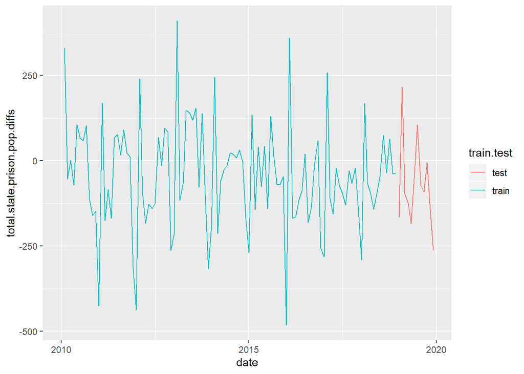

```r
ggplot2::ggplot(
  data.frame(
    date = zoo::index(train_df_stry),
    zoo::coredata(train_df_stry)
  ) %>%
    dplyr::bind_rows(
      data.frame(
        date = zoo::index(test_df_stry),
        zoo::coredata(test_df_stry)
      )
    ) %>%
    dplyr::mutate(train.test = ifelse(date < as.Date("2019-01-01"),
                                      "train",
                                      "test")),
  ggplot2::aes(
    x = date,
    y = total.state.prison.pop.diffs,
    col = train.test
  )) +
  ggplot2::geom_line()
```

```r
train_df_stry_rdf <- data.frame(
  date = zoo::index(train_df_stry),
  zoo::coredata(train_df_stry)
) %>%
  tidyr::drop_na()

test_df_stry_rdf <- data.frame(
  date = zoo::index(test_df_stry),
  zoo::coredata(test_df_stry)
)

str(train_df_stry_rdf)
```

```
## 'data.frame':    107 obs. of  3 variables:
##  $ date                        : Date, format: "2010-02-01" "2010-03-01" ...
##  $ total.state.prison.pop.diffs: num  330 -53 1 -72 105 67 59 103 -112 -161 ...
##  $ total.nonfarm.employed.diffs: num  8.1 5.8 25.2 18.1 0 ...
```

```python
# Python

#Training model on training set

py_train_data_stry = r.train_df_stry_rdf

py_train_data_stry = py_train_data_stry.set_index('date')

py_test_data_stry = r.test_df_stry_rdf

py_test_data_stry = py_test_data_stry.set_index('date')


py_train_data_stry.head()
```

```
##             total.state.prison.pop.diffs  total.nonfarm.employed.diffs
## date
## 2010-02-01                         330.0                           8.1
## 2010-03-01                         -53.0                           5.8
## 2010-04-01                           1.0                          25.2
## 2010-05-01                         -72.0                          18.1
## 2010-06-01                         105.0                           0.0
```

```python
# Python

#Training model on training set
model = VAR(endog=py_train_data_stry.values)
model_fit = model.fit(2)

# make prediction on "test" set
prediction = model_fit.forecast(model_fit.endog, steps=len(py_test_data_stry))

prediction
```

```
## array([[-21.67981649,  -1.20385862],
##        [-35.84853668,   2.22209531],
##        [-54.21567396,   2.68524858],
##        [-52.87491408,   1.13084042],
##        [-44.42194739,   0.49861351],
##        [-42.97573098,   1.06493982],
##        [-46.5925841 ,   1.49810547],
##        [-48.16160301,   1.34092588],
##        [-46.86395116,   1.09975398],
##        [-45.81048428,   1.11344767],
##        [-46.1556112 ,   1.22937696],
##        [-46.73260729,   1.25166808]])
```

### Call the Python predictions array in R using “py$”

```r
diffd_preds <- py$prediction

diffd_preds
```

```
##            [,1]       [,2]
##  [1,] -21.67982 -1.2038586
##  [2,] -35.84854  2.2220953
##  [3,] -54.21567  2.6852486
##  [4,] -52.87491  1.1308404
##  [5,] -44.42195  0.4986135
##  [6,] -42.97573  1.0649398
##  [7,] -46.59258  1.4981055
##  [8,] -48.16160  1.3409259
##  [9,] -46.86395  1.0997540
## [10,] -45.81048  1.1134477
## [11,] -46.15561  1.2293770
## [12,] -46.73261  1.2516681
```

### Convert this differenced values back to prison population predicted values

```r
# Calculate the actual predicted values after reconstructing the "differenced" predictions
pop_preds <- c(train_df$total.state.prison.pop[train_df$date == max(train_df$date)],
               rep(NA, 12))

for (i in 1:12) {

  pop_preds[i+1] <- pop_preds[i] + diffd_preds[i]

}

pop_preds <- pop_preds[-1]

pop_preds
```

```
##  [1] 13373.32 13337.47 13283.26 13230.38 13185.96 13142.98 13096.39
##  [8] 13048.23 13001.37 12955.55 12909.40 12862.67
```

### Visualize Actuals vs. the Predictions

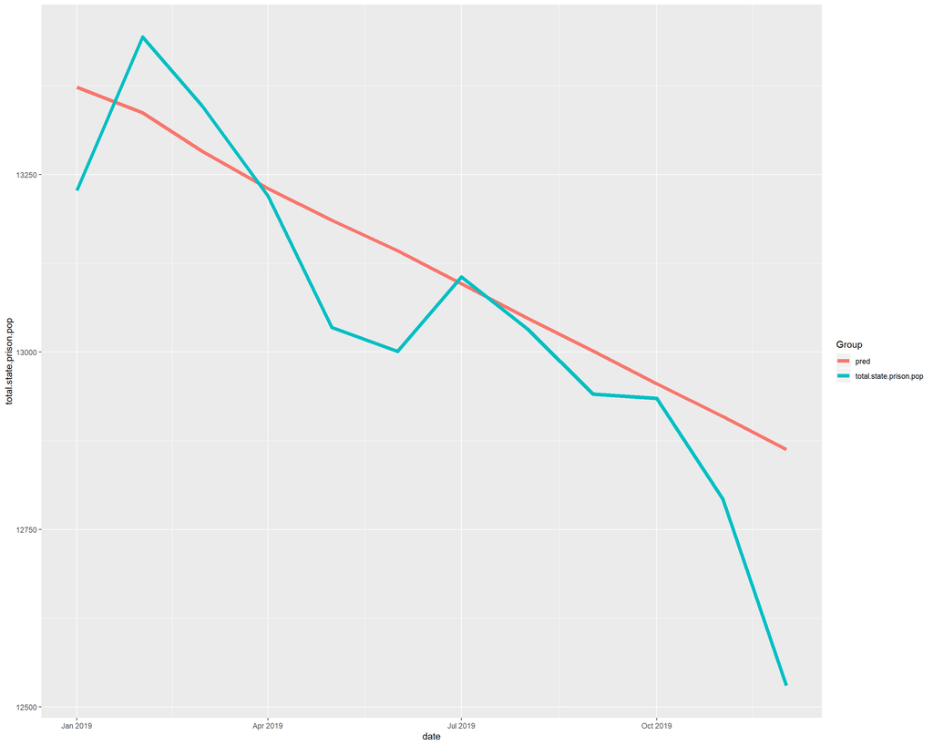

```r
test_df %>%
  dplyr::select(-total.nonfarm.employed) %>%
  dplyr::mutate(pred = pop_preds) %>%
  tidyr::pivot_longer(-date, names_to = "Group", values_to = "total.state.prison.pop") %>%
  ggplot2::ggplot(
    ggplot2::aes(x = date,
                 y = total.state.prison.pop,
                 col = Group)
  ) +
  ggplot2::geom_line(size = 2)
```